# Credit Scoring with R

Gerardo Alcala

January 2018

## Credit Scoring: an Introduction.

Credit scoring refers to an analysis made by lenders and banks to extended credit (or not) to customers. It has many applications within the financial industry as it automated the underwriting process substantially and allows to derive more sophisticated products to final customers (Risk based pricing is an example).

What I’m going to do is show the versatility of **R** to deal with a dataset ready to perform analysis and model. Obviously, as it is the case with most applications, the real deal comes when you have to collect the data, define what is a **bad** customers and so on.

This example also illustrated the ease to build your own functions to perform the computations required to obtain a model. **R** has many functions built in different packages that help you process your functions through datasets with much control on the output and inputs.

## The Data

The dataset comes from the Kaggle Competition [Give me some credit](https://www.kaggle.com/c/GiveMeSomeCredit) which consists in a small dataset of 150,000 observations with 10 predictors. We proceed to read and inspect the data, and rename our columns to more suitable and understandable names of our liking.

```r
data <- read_csv("C:/Users/galcala/Loan/cs-training.csv")
data.tbl <- as_tibble(data.frame(data))
typeof(data.tbl)
```

```
## [1] "list"
```

```r
glimpse(data.tbl)
```

```
## Observations: 150,000
## Variables: 12
## $ X1                                   <int> 1, 2, 3, 4, 5, 6, 7, 8, 9...
## $ SeriousDlqin2yrs                     <int> 1, 0, 0, 0, 0, 0, 0, 0, 0...
## $ RevolvingUtilizationOfUnsecuredLines <dbl> 0.76612661, 0.95715102, 0...
## $ age                                  <int> 45, 40, 38, 30, 49, 74, 5...
## $ NumberOfTime30.59DaysPastDueNotWorse <int> 2, 0, 1, 0, 1, 0, 0, 0, 0...
## $ DebtRatio                            <dbl> 8.029821e-01, 1.218762e-0...
## $ MonthlyIncome                        <int> 9120, 2600, 3042, 3300, 6...
## $ NumberOfOpenCreditLinesAndLoans      <int> 13, 4, 2, 5, 7, 3, 8, 8, ...
## $ NumberOfTimes90DaysLate              <int> 0, 0, 1, 0, 0, 0, 0, 0, 0...
## $ NumberRealEstateLoansOrLines         <int> 6, 0, 0, 0, 1, 1, 3, 0, 0...
## $ NumberOfTime60.89DaysPastDueNotWorse <int> 0, 0, 0, 0, 0, 0, 0, 0, 0...
## $ NumberOfDependents                   <int> 2, 1, 0, 0, 0, 1, 0, 0, N...
```

```r
data.tbl$X1 <- NULL
colnames(data.tbl) <- c("bad","revUtilUnsec","age","n30_59dpd_nw","debtRatio","mIncome","nOpenTrades",
                        "n90dlate","nREstate","n60_89dpd_nw","nDependents")
```

Alright, seems like our data is well read. Let us split it into training and testing for modelling purposes and work our way through the data.  
A very useful tool for inspecting variables (univariate) is the Desc function from the DescTools package, as it gives you many relevant statistics and information as well as useful plots to understand the distributions.

```r
set.seed(43)
inTrain <- createDataPartition(y=data.tbl$bad,p = .8, list = FALSE)
training <- data.tbl[inTrain,]
testing <- data.tbl[-inTrain,]
Desc(training)
```

```
## -------------------------------------------------------------------------
## Describe training (tbl_df, tbl, data.frame):
##
## data.frame:  120000 obs. of  11 variables
##
##   Nr  ColName       Class    NAs            Levels
##   1   bad           integer      .
##   2   revUtilUnsec  numeric      .
##   3   age           integer      .
##   4   n30_59dpd_nw  integer      .
##   5   debtRatio     numeric      .
##   6   mIncome       integer  23800 (19.8%)
##   7   nOpenTrades   integer      .
##   8   n90dlate      integer      .
##   9   nREstate      integer      .
##   10  n60_89dpd_nw  integer      .
##   11  nDependents   integer   3124 (2.6%)
##
##
## -------------------------------------------------------------------------
## 1 - bad (integer - dichotomous)
##
##    length       n     NAs  unique
##   120'000 120'000       0       2
##            100.0%    0.0%
##
##       freq   perc  lci.95  uci.95'
## 0  112'011  93.3%   93.2%   93.5%
## 1    7'989   6.7%    6.5%    6.8%
##
## ' 95%-CI Wilson
```

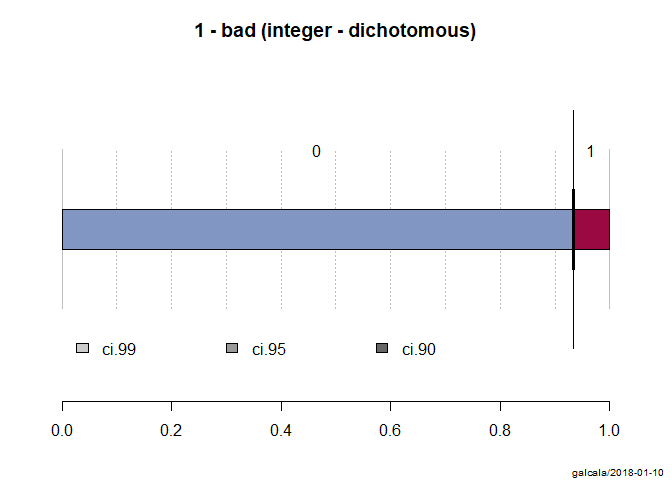

```
## -------------------------------------------------------------------------
## 2 - revUtilUnsec (numeric)
##
##              length               n            NAs        unique
##             120'000         120'000              0       100'932
##                              100.0%           0.0%
##
##                 .05             .10            .25        median
##        0.0000000000    0.0028972975   0.0296432087  0.1534955235
##
##               range              sd          vcoef           mad
##   20'514.0000000000  187.4560832479  34.7373068442  0.2190202689
##
##             0s           mean            meanCI
##          8'783   5.3963908051      4.3357669593
##           7.3%                     6.4570146509
##
##            .75            .90               .95
##   0.5570617472   0.9811474900      0.9999999000
##
##            IQR           skew              kurt
##   0.5274185385  57.3508264716  4'203.3035507492
##
## lowest : 0.0 (8'783), 0.00000993, 0.0000125, 0.0000143, 0.0000149
## highest: 13'400.0, 13'498.0, 17'441.0, 18'300.0, 20'514.0
```

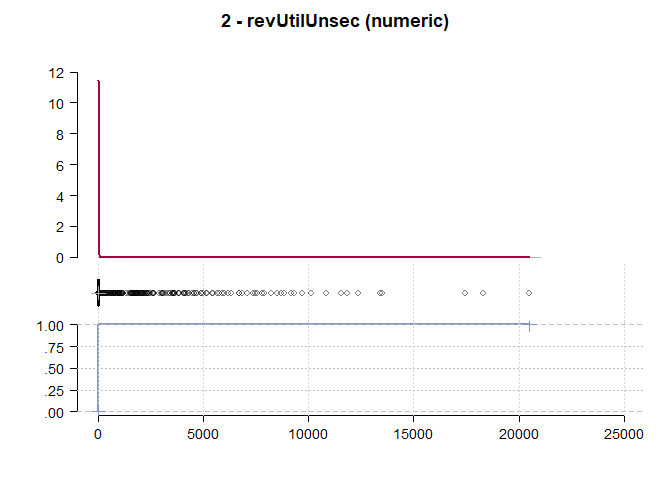

```
## -------------------------------------------------------------------------
## 3 - age (integer)
##
##    length        n    NAs  unique     0s   mean  meanCI
##   120'000  120'000      0      85      1  52.31   52.23
##             100.0%   0.0%           0.0%          52.40
##
##       .05      .10    .25  median    .75    .90     .95
##     29.00    33.00  41.00   52.00  63.00  72.00   78.00
##
##     range       sd  vcoef     mad    IQR   skew    kurt
##    109.00    14.78   0.28   16.31  22.00   0.19   -0.50
##
## lowest : 0, 21 (160), 22 (333), 23 (543), 24 (635)
## highest: 101 (2), 102, 103 (3), 107, 109 (2)
```

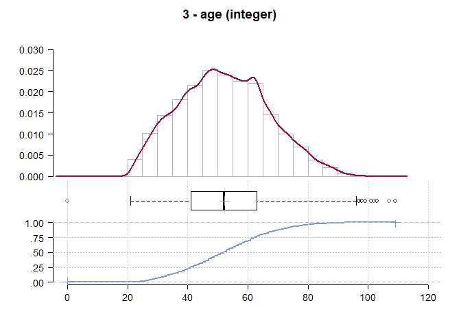

```
## -------------------------------------------------------------------------
## 4 - n30_59dpd_nw (integer)
##
##    length        n    NAs  unique       0s   mean  meanCI
##   120'000  120'000      0      16  100'908   0.42    0.40
##             100.0%   0.0%            84.1%           0.45
##
##       .05      .10    .25  median      .75    .90     .95
##      0.00     0.00   0.00    0.00     0.00   1.00    2.00
##
##     range       sd  vcoef     mad      IQR   skew    kurt
##     98.00     4.24  10.02    0.00     0.00  22.38  511.90
##
## lowest : 0 (100'908), 1 (12'766), 2 (3'668), 3 (1'397), 4 (602)
## highest: 11, 12 (2), 13, 96 (4), 98 (216)
```

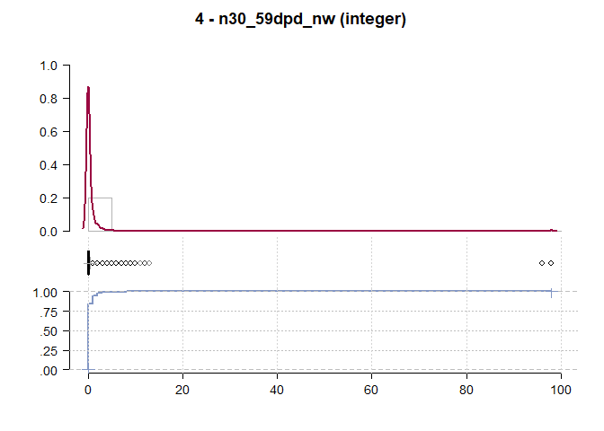

```
## -------------------------------------------------------------------------
## 5 - debtRatio (numeric)
##
##               length                 n           NAs        unique
##              120'000           120'000             0        93'091
##                                 100.0%          0.0%
##
##                  .05               .10           .25        median
##         0.0041962801      0.0303933134  0.1746868008  0.3655131565
##
##                range                sd         vcoef           mad
##   329'664.0000000000  1'962.6860436419  5.5812712114  0.3634767527
##
##             0s              mean             meanCI
##          3'341    351.6557374292     340.5508877834
##           2.8%                       362.7605870751
##
##            .75               .90                .95
##   0.8686527818  1'265.0000000000   2'447.0000000000
##
##            IQR              skew               kurt
##   0.6939659810     92.7561410895  13'505.0802601446
##
## lowest : 0.0 (3'341), 0.000026, 0.0000369, 0.0000393, 0.000075
## highest: 106'885.0, 168'835.0, 220'516.0, 307'001.0, 329'664.0
```

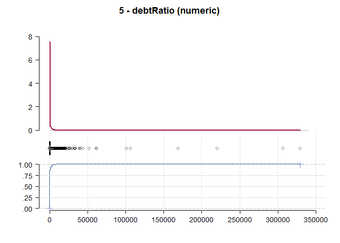

```
## -------------------------------------------------------------------------
## 6 - mIncome (integer)
##
##         length          n       NAs    unique        0s       mean
##        120'000     96'200    23'800    12'652     1'293   6'686.68
##                     80.2%     19.8%                1.1%
##
##            .05        .10       .25    median       .75        .90
##       1'300.00   2'000.00  3'400.00  5'400.00  8'250.00  11'666.00
##
##          range         sd     vcoef       mad       IQR       skew
##   3'008'750.00  15'532.50      2.32  3'445.56  4'850.00     111.82
##
##      meanCI
##    6'588.53
##    6'784.83
##
##         .95
##   14'600.00
##
##        kurt
##   17'882.65
##
## lowest : 0 (1'293), 1 (488), 2 (6), 4 (2), 5 (2)
## highest: 835'040, 1'072'500, 1'560'100, 1'794'060, 3'008'750
```

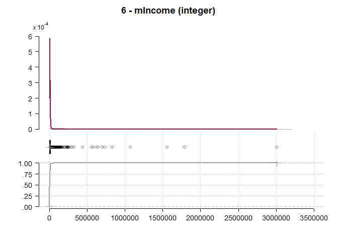

```
## -------------------------------------------------------------------------
## 7 - nOpenTrades (integer)
##
##    length        n    NAs  unique     0s   mean  meanCI
##   120'000  120'000      0      58  1'528   8.45    8.42
##             100.0%   0.0%           1.3%           8.48
##
##       .05      .10    .25  median    .75    .90     .95
##      2.00     3.00   5.00    8.00  11.00  15.00   18.00
##
##     range       sd  vcoef     mad    IQR   skew    kurt
##     58.00     5.15   0.61    4.45   6.00   1.21    3.05
##
## lowest : 0 (1'528), 1 (3'585), 2 (5'322), 3 (7'266), 4 (9'248)
## highest: 53, 54 (3), 56 (2), 57, 58
```

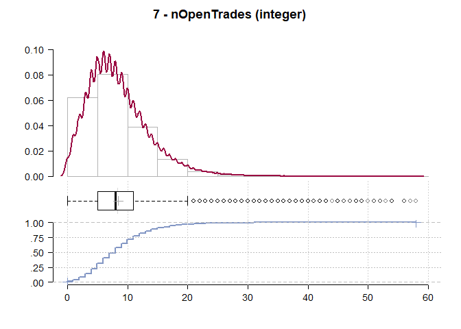

```
## -------------------------------------------------------------------------
## 8 - n90dlate (integer)
##
##    length        n    NAs  unique       0s   mean  meanCI
##   120'000  120'000      0      19  113'346   0.27    0.25
##             100.0%   0.0%            94.5%           0.29
##
##       .05      .10    .25  median      .75    .90     .95
##      0.00     0.00   0.00    0.00     0.00   0.00    1.00
##
##     range       sd  vcoef     mad      IQR   skew    kurt
##     98.00     4.22  15.61    0.00     0.00  22.84  526.08
##
## lowest : 0 (113'346), 1 (4'158), 2 (1'255), 3 (537), 4 (235)
## highest: 14 (2), 15 (2), 17, 96 (4), 98 (216)
```

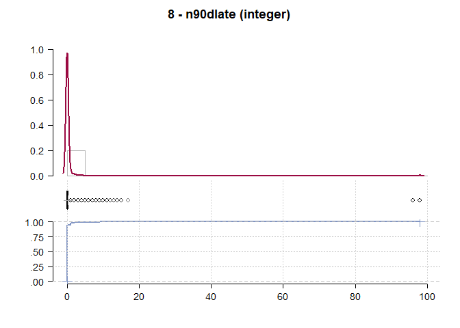

```
## -------------------------------------------------------------------------
## 9 - nREstate (integer)
##
##    length        n    NAs  unique      0s  mean  meanCI
##   120'000  120'000      0      28  45'027  1.02    1.01
##             100.0%   0.0%           37.5%          1.02
##
##       .05      .10    .25  median     .75   .90     .95
##      0.00     0.00   0.00    1.00    2.00  2.00    3.00
##
##     range       sd  vcoef     mad     IQR  skew    kurt
##     54.00     1.14   1.12    1.48    2.00  3.79   70.98
##
## lowest : 0 (45'027), 1 (41'850), 2 (25'172), 3 (5'022), 4 (1'743)
## highest: 25 (3), 26, 29, 32, 54
```

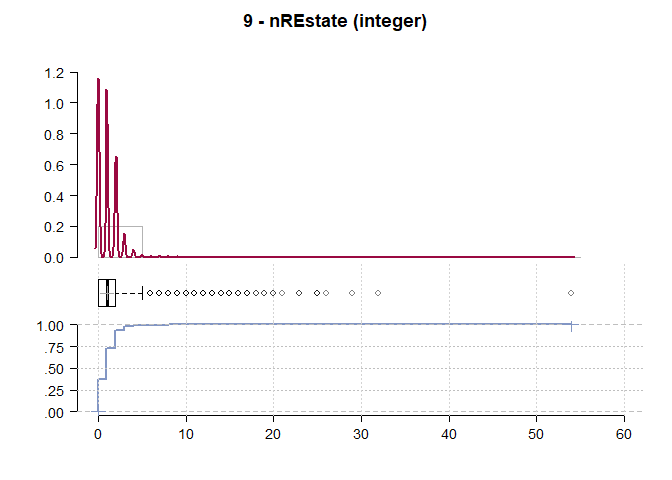

```
## -------------------------------------------------------------------------
## 10 - n60_89dpd_nw (integer)
##
##    length        n    NAs  unique       0s   mean  meanCI
##   120'000  120'000      0      12  113'950   0.24    0.22
##             100.0%   0.0%            95.0%           0.27
##
##       .05      .10    .25  median      .75    .90     .95
##      0.00     0.00   0.00    0.00     0.00   0.00    1.00
##
##     range       sd  vcoef     mad      IQR   skew    kurt
##     98.00     4.20  17.23    0.00     0.00  23.08  533.83
##
##
##     level     freq   perc  cumfreq  cumperc
## 1       0  113'950  95.0%  113'950    95.0%
## 2       1    4'559   3.8%  118'509    98.8%
## 3       2      888   0.7%  119'397    99.5%
## 4       3      251   0.2%  119'648    99.7%
## 5       4       80   0.1%  119'728    99.8%
## 6       5       29   0.0%  119'757    99.8%
## 7       6       11   0.0%  119'768    99.8%
## 8       7        9   0.0%  119'777    99.8%
## 9       8        2   0.0%  119'779    99.8%
## 10     11        1   0.0%  119'780    99.8%
## 11     96        4   0.0%  119'784    99.8%
## 12     98      216   0.2%  120'000   100.0%
```

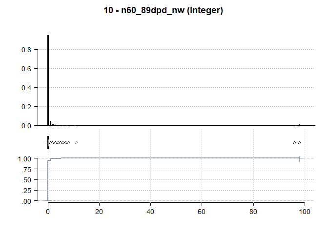

```
## -------------------------------------------------------------------------
## 11 - nDependents (integer)
##
##    length        n    NAs  unique      0s  mean  meanCI
##   120'000  116'876  3'124      13  69'625  0.76    0.75
##              97.4%   2.6%           58.0%          0.76
##
##       .05      .10    .25  median     .75   .90     .95
##      0.00     0.00   0.00    0.00    1.00  2.00    3.00
##
##     range       sd  vcoef     mad     IQR  skew    kurt
##     20.00     1.12   1.48    0.00    1.00  1.60    3.20
##
## lowest : 0 (69'625), 1 (21'010), 2 (15'561), 3 (7'588), 4 (2'303)
## highest: 8 (20), 9 (5), 10 (4), 13, 20
```

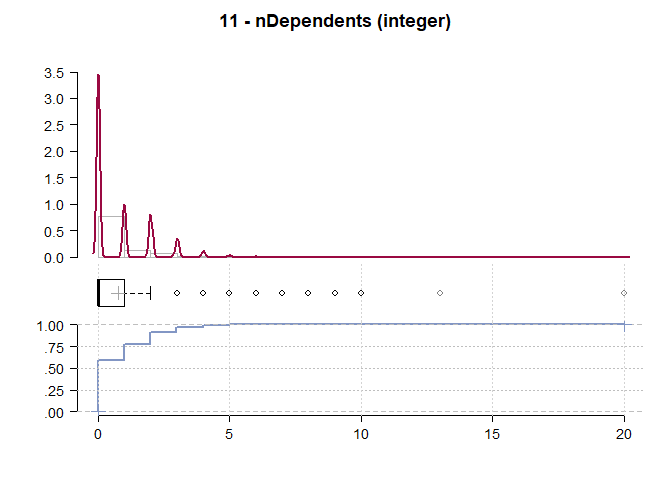